# Content

1. Load Libraries
2. Load Dataset
3. Exploratory Data Analysis (EDA)
4. Visualizing — Categorical Variables
5. Visualizing — Numeric Variables
6. Feature Engineering
1. Drop Outliers
2. Define Inputs
3. Log Transformations
4. One Hot Encoding
5. Define Target Feature and One Hot Encoding
7. Prepare Imbalanced Dataset for Classification
1. Evaluate Data Oversampling Models
2. Evaluate Machine Learning Models
3. Choose Best Models
4. Results On Graph
5. Choose The Best Models and Make Hyper Parameters Tuning
8. Customer Segmentation
1. Find Recency, Monetary and Frequency
2. RFM Segmentation
3. Who are my best customers?
4. Summing the RFM Score
5. Making Segmentation For Customers Depends On RFM Sum Score

## Load Libraries

```python
import numpy as np
import pandas as pd
import matplotlib.pyplot as plt
import plotly
import plotly.figure_factory as ff
from plotly.graph_objs import Scatter, Layout
import plotly.offline as pyo
import plotly.graph_objs as go
%matplotlib inline
#
from sklearn.model_selection import RepeatedStratifiedKFold
from sklearn.model_selection import KFold
from sklearn.model_selection import cross_val_score
from sklearn.model_selection import train_test_split
from sklearn.preprocessing import StandardScaler
from sklearn.model_selection import GridSearchCV
#
from sklearn.linear_model import LogisticRegression
from sklearn.tree import DecisionTreeClassifier
from sklearn.neighbors import KNeighborsClassifier
from sklearn.ensemble import RandomForestClassifier
from sklearn.naive_bayes import GaussianNB
from sklearn.svm import SVC
from sklearn.tree import DecisionTreeClassifier
#
from sklearn.ensemble import AdaBoostClassifier
from sklearn.ensemble import GradientBoostingClassifier
from sklearn.ensemble import RandomForestClassifier
from sklearn.ensemble import ExtraTreesClassifier
#
from xgboost import XGBClassifier
from sklearn.neural_network import MLPClassifier
#
from imblearn.over_sampling import RandomOverSampler
from imblearn.over_sampling import SMOTE
from imblearn.over_sampling import BorderlineSMOTE
from imblearn.over_sampling import SVMSMOTE
from imblearn.over_sampling import ADASYN
#
from sklearn.metrics import classification_report
from sklearn.metrics import confusion_matrix
from sklearn.metrics import accuracy_score
#
from imblearn.pipeline import Pipeline
from sklearn.preprocessing import MinMaxScaler
import itertools
import seaborn as sns
plotly.offline.init_notebook_mode(connected=True)
from plotly.offline import download_plotlyjs, init_notebook_mode, plot, iplot
#
pd.set_option('display.max_columns', None)
pd.set_option('display.max_rows', None)
#
import warnings
warnings.filterwarnings("ignore")
```

## Load Dataset

```python
df = pd.read_csv("term-deposit-marketing-2020.csv")
df.head()
```

|  | age | job | marital | education | default | balance | housing | loan | contact | day | month | duration | campaign | y |
| --- | --- | --- | --- | --- | --- | --- | --- | --- | --- | --- | --- | --- | --- | --- |
| 0 | 58 | management | married | tertiary | no | 2143 | yes | no | unknown | 5 | may | 261 | 1 | no |
| 1 | 44 | technician | single | secondary | no | 29 | yes | no | unknown | 5 | may | 151 | 1 | no |
| 2 | 33 | entrepreneur | married | secondary | no | 2 | yes | yes | unknown | 5 | may | 76 | 1 | no |
| 3 | 47 | blue-collar | married | unknown | no | 1506 | yes | no | unknown | 5 | may | 92 | 1 | no |
| 4 | 33 | unknown | single | unknown | no | 1 | no | no | unknown | 5 | may | 198 | 1 | no |

- Data Description:
  - The marketing campaign involves making a phone call to a customer, often multiple times to ensure a product subscription, in this case a term deposit. Term deposits are usually short-term deposits with maturities ranging from one month to a few years. The customer must understand when buying a term deposit that they can withdraw their funds only after the term ends. All customer information that might reveal personal information is removed due to privacy concerns.
- Attributes:
  - age : age of customer (numeric)
  - job : type of job (categorical)
  - marital : marital status (categorical)
  - education (categorical)
  - default: has credit in default? (binary)
  - balance: average yearly balance, in euros (numeric)
  - housing: has a housing loan? (binary)
  - loan: has personal loan? (binary)
  - contact: contact communication type (categorical)
  - day: last contact day of the month (numeric)
  - month: last contact month of year (categorical)
  - duration: last contact duration, in seconds (numeric)
  - campaign: number of contacts performed during this campaign and for this client (numeric, includes last contact)
- Output (desired target):
  - y - has the client subscribed to a term deposit? (binary)
- Goal(s):
  - Predict if the customer will subscribe (yes/no) to a term deposit (variable y)
- Success Metric(s):
  - Hit %81 or above accuracy by evaluating with 5-fold cross validation and reporting the average performance score.
- Bonus(es):
  - We are also interested in finding customers who are more likely to buy the investment product. Determine the segment(s) of customers our client should prioritize.
  - What makes the customers buy? Tell us which feature we should be focusing more on.

## Exploratory Data Analysis (EDA)

```python
# Shape of Dataset
df.shape
```

```
(40000, 14)
```

```python
# Info of Dataset
df.info()
```

```
<class 'pandas.core.frame.DataFrame'>
RangeIndex: 40000 entries, 0 to 39999
Data columns (total 14 columns):
 #   Column     Non-Null Count  Dtype
---  ------     --------------  -----
 0   age        40000 non-null  int64
 1   job        40000 non-null  object
 2   marital    40000 non-null  object
 3   education  40000 non-null  object
 4   default    40000 non-null  object
 5   balance    40000 non-null  int64
 6   housing    40000 non-null  object
 7   loan       40000 non-null  object
 8   contact    40000 non-null  object
 9   day        40000 non-null  int64
 10  month      40000 non-null  object
 11  duration   40000 non-null  int64
 12  campaign   40000 non-null  int64
 13  y          40000 non-null  object
dtypes: int64(5), object(9)
memory usage: 4.3+ MB
```

```python
# Describe of Dataset
df.describe().T
```

|  | count | mean | std | min | 25% | 50% | 75% | max |
| --- | --- | --- | --- | --- | --- | --- | --- | --- |
| age | 40000.0 | 40.544600 | 9.641776 | 19.0 | 33.0 | 39.0 | 48.0 | 95.0 |
| balance | 40000.0 | 1274.277550 | 2903.769716 | -8019.0 | 54.0 | 407.0 | 1319.0 | 102127.0 |
| day | 40000.0 | 16.017225 | 8.278127 | 1.0 | 8.0 | 17.0 | 21.0 | 31.0 |
| duration | 40000.0 | 254.824300 | 259.366498 | 0.0 | 100.0 | 175.0 | 313.0 | 4918.0 |
| campaign | 40000.0 | 2.882175 | 3.239051 | 1.0 | 1.0 | 2.0 | 3.0 | 63.0 |

```python
# Correlation
df.corr()
```

|  | age | balance | day | duration | campaign |
| --- | --- | --- | --- | --- | --- |
| age | 1.000000 | 0.081517 | -0.011689 | -0.036270 | 0.016204 |
| balance | 0.081517 | 1.000000 | 0.011662 | 0.014072 | -0.008137 |
| day | -0.011689 | 0.011662 | 1.000000 | -0.032983 | 0.165429 |
| duration | -0.036270 | 0.014072 | -0.032983 | 1.000000 | -0.088387 |
| campaign | 0.016204 | -0.008137 | 0.165429 | -0.088387 | 1.000000 |

```python
# Distribution of Target
df.y.value_counts(normalize=True)
```

```
no     0.9276
yes    0.0724
Name: y, dtype: float64
```

## Visualizing — Categorical Variables

```python
data = [go.Bar(
    x=df.marital.value_counts().index.tolist(),
    y=df.marital.value_counts().tolist(),
    text=df.marital.value_counts().tolist(),
    textposition='auto'
)]
layout = go.Layout(
    title='Marital Counts'
)
fig = go.Figure(data=data, layout=layout)
iplot(fig)
```

[interactive chart not shown]

```python
data = [go.Bar(
    x=df.job.value_counts().index.tolist(),
    y=df.job.value_counts().tolist(),
    text=df.job.value_counts().tolist(),
    textposition='auto'
)]
layout = go.Layout(
    title='Job Distribution'
)
fig = go.Figure(data=data, layout=layout)
iplot(fig)
```

[interactive chart not shown]

```python
data = [go.Bar(
    x=df.education.value_counts().index.tolist(),
    y=df.education.value_counts().tolist(),
    text=df.education.value_counts().tolist(),
    textposition='auto'
)]
layout = go.Layout(
    title='Education Distribution'
)
fig = go.Figure(data=data, layout=layout)
iplot(fig)
```

[interactive chart not shown]

```python
data = [go.Bar(
    x=df.default.value_counts().index.tolist(),
    y=df.default.value_counts().tolist(),
    text=df.default.value_counts().tolist(),
    textposition='auto'
)]
layout = go.Layout(
    title='Has a Housing Loan?'
)
fig = go.Figure(data=data, layout=layout)
iplot(fig)
```

[interactive chart not shown]

```python
data = [go.Bar(
    x=df.housing.value_counts().index.tolist(),
    y=df.housing.value_counts().tolist(),
    text=df.housing.value_counts().tolist(),
    textposition='auto'
)]
layout = go.Layout(
    title='Has a Housing Loan?'
)
fig = go.Figure(data=data, layout=layout)
iplot(fig)
```

[interactive chart not shown]

```python
data = [go.Bar(
    x=df.loan.value_counts().index.tolist(),
    y=df.loan.value_counts().tolist(),
    text=df.loan.value_counts().tolist(),
    textposition='auto'
)]
layout = go.Layout(
    title='Has Personal Loan?'
)
fig = go.Figure(data=data, layout=layout)
iplot(fig)
```

[interactive chart not shown]

```python
data = [go.Bar(
    x=df.contact.value_counts().index.tolist(),
    y=df.contact.value_counts().tolist(),
    text=df.contact.value_counts().tolist(),
    textposition='auto'
)]
layout = go.Layout(
    title='Contact Communication Type'
)
fig = go.Figure(data=data, layout=layout)
iplot(fig)
```

[interactive chart not shown]

```python
data = [go.Bar(
    x=df.month.value_counts().index.tolist(),
    y=df.month.value_counts().tolist(),
    text=df.month.value_counts().tolist(),
    textposition='auto'
)]
layout = go.Layout(
    title='Last Contact Month of Year '
)
fig = go.Figure(data=data, layout=layout)
iplot(fig)
```

[interactive chart not shown]

```python
data = [go.Bar(
    x=df.y.value_counts().index.tolist(),
    y=df.y.value_counts().tolist(),
    text=df.y.value_counts(normalize=True)*100,
    textposition='auto'
)]
layout = go.Layout(
    title='Has The Client Subscribed to a Term Deposit?'
)
fig = go.Figure(data=data, layout=layout)
iplot(fig)
```

[interactive chart not shown]

## Visualizing — Numeric Variables

```python
from scipy import stats
from scipy.stats import norm, skew
```

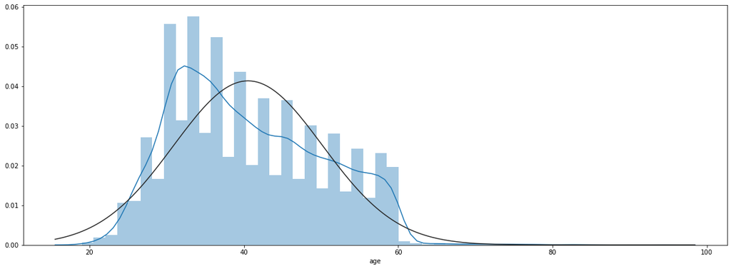

```python
f,ax = plt.subplots(figsize = (20,7))
sns.distplot(df.age, fit=norm);
```

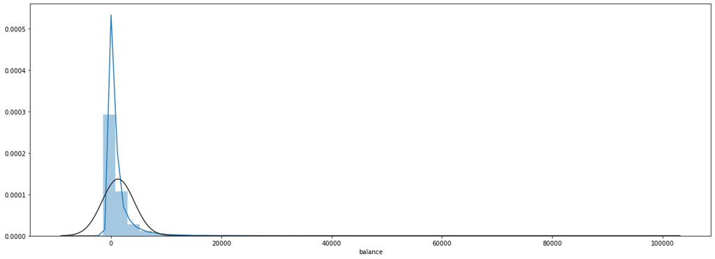

```python
f,ax = plt.subplots(figsize = (20,7))
sns.distplot(df.balance, fit=norm);
```

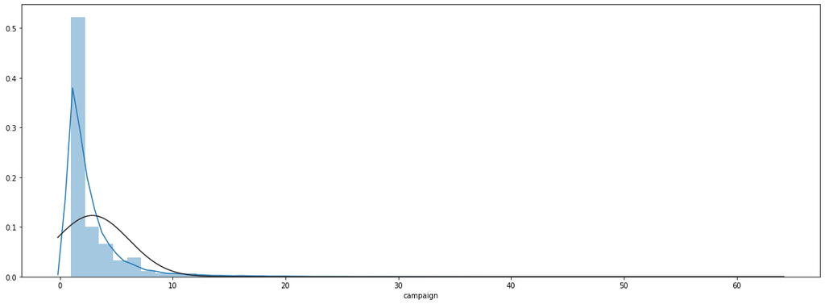

```python
f,ax = plt.subplots(figsize = (20,7))
sns.distplot(df.campaign, fit=norm);
```

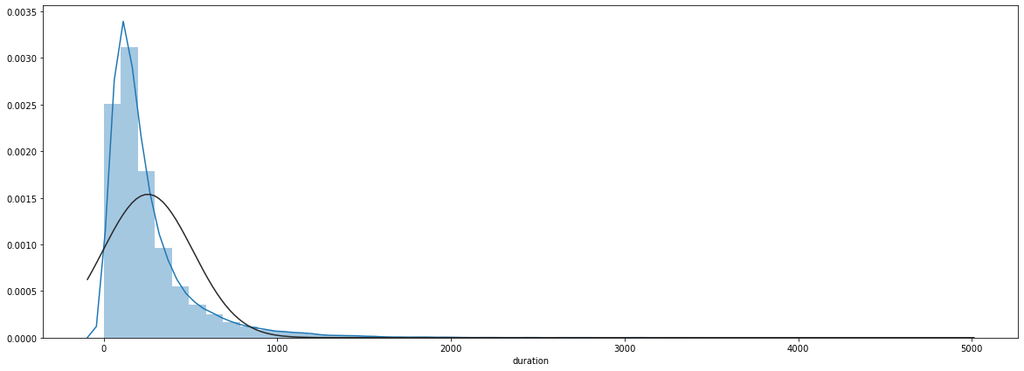

```python
f,ax = plt.subplots(figsize = (20,7))
sns.distplot(df.duration, fit=norm);
```

## Feature Engineering

```python
df.head()
```

|  | age | job | marital | education | default | balance | housing | loan | contact | day | month | duration | campaign | y |
| --- | --- | --- | --- | --- | --- | --- | --- | --- | --- | --- | --- | --- | --- | --- |
| 0 | 58 | management | married | tertiary | no | 2143 | yes | no | unknown | 5 | may | 261 | 1 | no |
| 1 | 44 | technician | single | secondary | no | 29 | yes | no | unknown | 5 | may | 151 | 1 | no |
| 2 | 33 | entrepreneur | married | secondary | no | 2 | yes | yes | unknown | 5 | may | 76 | 1 | no |
| 3 | 47 | blue-collar | married | unknown | no | 1506 | yes | no | unknown | 5 | may | 92 | 1 | no |
| 4 | 33 | unknown | single | unknown | no | 1 | no | no | unknown | 5 | may | 198 | 1 | no |

### Drop Outliers

```python
# For "Age"
threshoold         = 1.5
acceleration_desc  = df["age"].describe()
q3_age             = acceleration_desc[6]
q1_age             = acceleration_desc[4]
IQR_age            = q3_age - q1_age
top_limit_age      = q3_age + threshoold * IQR_age
bottom_limit_age   = q1_age - threshoold * IQR_age
filter_age_bottom  = bottom_limit_age < df["age"]
filter_age_top     = df["age"] < top_limit_age
filter_age         = filter_age_bottom & filter_age_top
```

```python
df.shape
```

```
(40000, 14)
```

```python
df = df[filter_age]
df.shape
```

```
(39921, 14)
```

```python
# For "Duration"
threshoold         = 1.5
acceleration_desc  = df["duration"].describe()
q3_dur             = acceleration_desc[6]
q1_dur             = acceleration_desc[4]
IQR_dur            = q3_dur - q1_dur
top_limit_dur      = q3_dur + threshoold * IQR_dur
bottom_limit_dur   = q1_dur - threshoold * IQR_dur
filter_dur_bottom  = bottom_limit_dur < df["duration"]
filter_dur_top     = df["duration"] < top_limit_dur
filter_dur         = filter_dur_bottom & filter_dur_top
```

```python
df = df[filter_age]
df.shape
```

```
(39921, 14)
```

### Define Inputs

```python
# Define Inputs:
x = df.iloc[:,[0,1,2,3,4,6,7,8,11,12]]
```

### Log Transformations

- The log transformation can be used to make highly skewed distributions less skewed.

```python
x["age"] = np.log1p(x["age"])
```

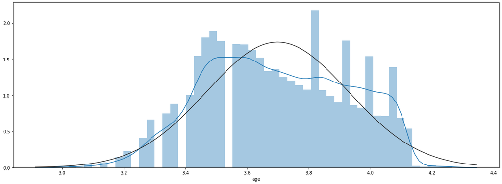

```python
f,ax = plt.subplots(figsize = (20,7))
sns.distplot(x.age, fit=norm);
```

```python
x["duration"] = np.log1p(x["duration"])
```

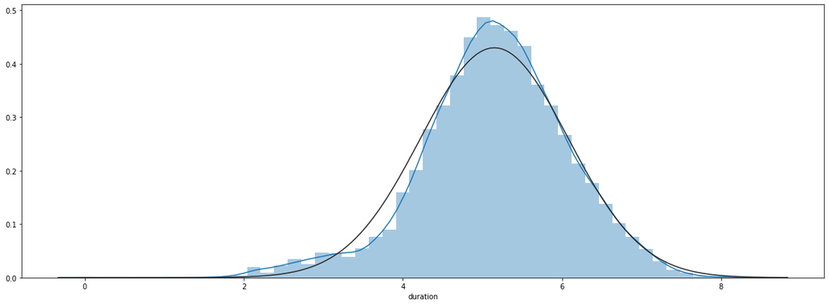

```python
f,ax = plt.subplots(figsize = (20,7))
sns.distplot(x.duration, fit=norm);
```

### One Hot Encoding

```python
# One-Hot Enc. for Categoric Features
X = pd.get_dummies(x,drop_first=True)
X.head()
```

|  | age | duration | campaign | job_blue-collar | job_entrepreneur | job_housemaid | job_management | job_retired | job_self-employed | job_services | ... | marital_married | marital_single | education_secondary | education_tertiary | education_unknown | default_yes | housing_yes | loan_yes | contact_telephone | contact_unknown |
| --- | --- | --- | --- | --- | --- | --- | --- | --- | --- | --- | --- | --- | --- | --- | --- | --- | --- | --- | --- | --- | --- |
| 0 | 4.077537 | 5.568345 | 1 | 0 | 0 | 0 | 1 | 0 | 0 | 0 | ... | 1 | 0 | 0 | 1 | 0 | 0 | 1 | 0 | 0 | 1 |
| 1 | 3.806662 | 5.023881 | 1 | 0 | 0 | 0 | 0 | 0 | 0 | 0 | ... | 0 | 1 | 1 | 0 | 0 | 0 | 1 | 0 | 0 | 1 |
| 2 | 3.526361 | 4.343805 | 1 | 0 | 1 | 0 | 0 | 0 | 0 | 0 | ... | 1 | 0 | 1 | 0 | 0 | 0 | 1 | 1 | 0 | 1 |
| 3 | 3.871201 | 4.532599 | 1 | 1 | 0 | 0 | 0 | 0 | 0 | 0 | ... | 1 | 0 | 0 | 0 | 1 | 0 | 1 | 0 | 0 | 1 |
| 4 | 3.526361 | 5.293305 | 1 | 0 | 0 | 0 | 0 | 0 | 0 | 0 | ... | 0 | 1 | 0 | 0 | 1 | 0 | 0 | 0 | 0 | 1 |

5 rows × 24 columns

### Define Target Feature and One Hot Encoding

```python
y = df.iloc[:,[13]]
Y = pd.get_dummies(y,drop_first=True)
```

## Prepare Imbalanced Dataset for Classification

### Evaluate Data Oversampling Models

```python
models, names = list(), list()
# RandomOverSampler
models.append(RandomOverSampler())
names.append('ROS')
# SMOTE
models.append(SMOTE())
names.append('SMOTE')
# BorderlineSMOTE
models.append(BorderlineSMOTE())
names.append('BLSMOTE')
# SVMSMOTE
models.append(SVMSMOTE())
names.append('SVMSMOTE')
# ADASYN
models.append(ADASYN())
names.append('ADASYN')
```

### Evaluate Machine Learning Models

```python
models_class = []
models_class.append(('LR', LogisticRegression()))
models_class.append(('KNN', KNeighborsClassifier()))
models_class.append(('SVM', SVC()))
models_class.append(('NB', GaussianNB()))
models_class.append(('DTC', DecisionTreeClassifier()))
models_class.append(('ABC', AdaBoostClassifier()))
models_class.append(('GBC', GradientBoostingClassifier()))
models_class.append(('RFC', RandomForestClassifier()))
models_class.append(('ETC', ExtraTreesClassifier()))
models_class.append(('XGB', XGBClassifier()))
models_class.append(('MLP', MLPClassifier()))
```

### Choose Best Models

```python
results = []
models_names = []
for i in range(len(models)):
    # define the model
    for name_class, model_class in models_class:
        #model = ExtraTreesClassifier(n_estimators=1000)
        # define the pipeline steps
        steps = [('s', MinMaxScaler()), ('o', models[i]), ('m', model_class)]
        # define the pipeline
        pipeline = Pipeline(steps=steps)
        # evaluate the model and store results
        kfold = KFold(n_splits=5, random_state=42)
        # evaluate model
        scores = cross_val_score(pipeline, X, Y, scoring='roc_auc', cv=kfold, n_jobs=-1)
        results.append(scores)
        models_names.append(names[i] + name_class)
        # summarize and store
        print("Model Name:{} Sample Name:{} Model ROC:{:.3f} Model Std:{:.3f}".format(name_class,names[i], scores.mean(), scores.std()))
```

```
Model Name:LR Sample Name:ROS Model ROC:0.903 Model Std:0.070
Model Name:KNN Sample Name:ROS Model ROC:0.734 Model Std:0.044
Model Name:SVM Sample Name:ROS Model ROC:0.894 Model Std:0.067
Model Name:NB Sample Name:ROS Model ROC:0.791 Model Std:0.052
Model Name:DTC Sample Name:ROS Model ROC:0.643 Model Std:0.039
Model Name:ABC Sample Name:ROS Model ROC:0.905 Model Std:0.066
Model Name:GBC Sample Name:ROS Model ROC:0.907 Model Std:0.067
Model Name:RFC Sample Name:ROS Model ROC:0.876 Model Std:0.076
Model Name:ETC Sample Name:ROS Model ROC:0.848 Model Std:0.072
Model Name:XGB Sample Name:ROS Model ROC:0.887 Model Std:0.069
Model Name:MLP Sample Name:ROS Model ROC:0.881 Model Std:0.069
Model Name:LR Sample Name:SMOTE Model ROC:0.902 Model Std:0.070
Model Name:KNN Sample Name:SMOTE Model ROC:0.758 Model Std:0.048
Model Name:SVM Sample Name:SMOTE Model ROC:0.891 Model Std:0.066
Model Name:NB Sample Name:SMOTE Model ROC:0.768 Model Std:0.054
Model Name:DTC Sample Name:SMOTE Model ROC:0.678 Model Std:0.034
Model Name:ABC Sample Name:SMOTE Model ROC:0.897 Model Std:0.067
Model Name:GBC Sample Name:SMOTE Model ROC:0.903 Model Std:0.069
Model Name:RFC Sample Name:SMOTE Model ROC:0.879 Model Std:0.073
Model Name:ETC Sample Name:SMOTE Model ROC:0.856 Model Std:0.071
Model Name:XGB Sample Name:SMOTE Model ROC:0.890 Model Std:0.067
Model Name:MLP Sample Name:SMOTE Model ROC:0.873 Model Std:0.067
Model Name:LR Sample Name:BLSMOTE Model ROC:0.902 Model Std:0.070
Model Name:KNN Sample Name:BLSMOTE Model ROC:0.758 Model Std:0.049
Model Name:SVM Sample Name:BLSMOTE Model ROC:0.890 Model Std:0.066
Model Name:NB Sample Name:BLSMOTE Model ROC:0.772 Model Std:0.054
Model Name:DTC Sample Name:BLSMOTE Model ROC:0.683 Model Std:0.040
Model Name:ABC Sample Name:BLSMOTE Model ROC:0.898 Model Std:0.068
Model Name:GBC Sample Name:BLSMOTE Model ROC:0.903 Model Std:0.068
Model Name:RFC Sample Name:BLSMOTE Model ROC:0.880 Model Std:0.073
Model Name:ETC Sample Name:BLSMOTE Model ROC:0.859 Model Std:0.073
Model Name:XGB Sample Name:BLSMOTE Model ROC:0.891 Model Std:0.066
Model Name:MLP Sample Name:BLSMOTE Model ROC:0.878 Model Std:0.068
Model Name:LR Sample Name:SVMSMOTE Model ROC:0.901 Model Std:0.072
Model Name:KNN Sample Name:SVMSMOTE Model ROC:0.757 Model Std:0.049
Model Name:SVM Sample Name:SVMSMOTE Model ROC:0.895 Model Std:0.068
Model Name:NB Sample Name:SVMSMOTE Model ROC:0.737 Model Std:0.060
Model Name:DTC Sample Name:SVMSMOTE Model ROC:0.681 Model Std:0.037
Model Name:ABC Sample Name:SVMSMOTE Model ROC:0.899 Model Std:0.067
Model Name:GBC Sample Name:SVMSMOTE Model ROC:0.902 Model Std:0.068
Model Name:RFC Sample Name:SVMSMOTE Model ROC:0.885 Model Std:0.073
Model Name:ETC Sample Name:SVMSMOTE Model ROC:0.858 Model Std:0.073
Model Name:XGB Sample Name:SVMSMOTE Model ROC:0.891 Model Std:0.067
Model Name:MLP Sample Name:SVMSMOTE Model ROC:0.881 Model Std:0.070
Model Name:LR Sample Name:ADASYN Model ROC:0.901 Model Std:0.069
Model Name:KNN Sample Name:ADASYN Model ROC:0.757 Model Std:0.046
Model Name:SVM Sample Name:ADASYN Model ROC:0.889 Model Std:0.065
Model Name:NB Sample Name:ADASYN Model ROC:0.772 Model Std:0.055
Model Name:DTC Sample Name:ADASYN Model ROC:0.685 Model Std:0.038
Model Name:ABC Sample Name:ADASYN Model ROC:0.896 Model Std:0.067
Model Name:GBC Sample Name:ADASYN Model ROC:0.902 Model Std:0.071
Model Name:RFC Sample Name:ADASYN Model ROC:0.876 Model Std:0.074
Model Name:ETC Sample Name:ADASYN Model ROC:0.855 Model Std:0.070
Model Name:XGB Sample Name:ADASYN Model ROC:0.890 Model Std:0.068
Model Name:MLP Sample Name:ADASYN Model ROC:0.871 Model Std:0.064
```

### Results On Graph

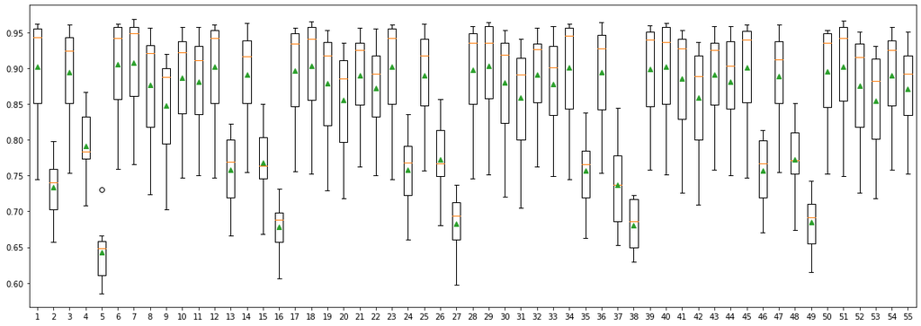

```python
# plot the results
from matplotlib import pyplot
f,ax = plt.subplots(figsize = (20,7))
pyplot.boxplot(results, showmeans=True)
pyplot.show()
```

### Choose The Best Models and Make Hyper Parameters Tuning

- Model Name:GBC Sample Name:ROS Model ROC:0.907 Model Std:0.067

#### ReSampling Model

```python
ros = RandomOverSampler(random_state=7)
x_resampled, y_resampled = ros.fit_sample(X,Y)
```

```python
x_resampled.shape, y_resampled.shape
```

```
((74124, 24), (74124, 1))
```

```python
# Creating Train and Test Datasets
x_train, x_test, y_train, y_test = train_test_split(x_resampled, y_resampled, test_size=0.33, random_state=42)
```

```python
x_train.shape, x_test.shape, y_train.shape, y_test.shape
```

```
((49663, 24), (24461, 24), (49663, 1), (24461, 1))
```

#### Tuning Classification Model

- it is taking a lot of time, so i will use default parameters.

```python
# Tuning Gradient Boosting Classifier
losses = ["deviance","exponential"]
learning_rates = [0.001, 0.01, 0.1, 1]
estimators = [10,50,100,150,200]
subsamples = [0.01, 0.1, 1, 5, 10, 15]
criterions = ["friedman_mse", "mse", "mae"]
param_grid = dict(criterion=criterions, loss=losses)
```

```python
gbc = GradientBoostingClassifier()
gs = GridSearchCV(estimator=gbc, param_grid=param_grid, scoring="roc_auc", cv=5)
grid_search = gs.fit(x_train,y_train)
best_score = grid_search.best_score_
best_parameters = grid_search.best_params_
print("Best Score:",best_score)
print("Best Parameters:",best_parameters)
```

#### Classification

```python
gbc = GradientBoostingClassifier()
gbc.fit(x_train,y_train)
y_pred = gbc.predict(x_test)
```

```python
#confussion matrix:
from sklearn import metrics
gbc_cm = confusion_matrix(y_test,y_pred)
gbc_acc = metrics.accuracy_score(y_test, y_pred)
print(gbc_cm)
```

```
[[10248  2008]
 [ 1801 10404]]
```

```python
# Accuracy
print(gbc_acc)
```

```
0.8442827357834921
```

```python
# Feature Importance

# You can see that we are given an importance score
# for each attribute where the larger the score,
# the more important the attribute.
feature = pd.DataFrame(data=[gbc.feature_importances_], columns=X.columns)
feature.head()
```

|  | age | duration | campaign | job_blue-collar | job_entrepreneur | job_housemaid | job_management | job_retired | job_self-employed | job_services | job_student | job_technician | job_unemployed | job_unknown | marital_married | marital_single | education_secondary | education_tertiary | education_unknown | default_yes | housing_yes | loan_yes | contact_telephone | contact_unknown |
| --- | --- | --- | --- | --- | --- | --- | --- | --- | --- | --- | --- | --- | --- | --- | --- | --- | --- | --- | --- | --- | --- | --- | --- | --- |
| 0 | 0.02877 | 0.80791 | 0.019613 | 0.002417 | 0.00127 | 0.000474 | 0.000126 | 0.000108 | 0.00011 | 0.001047 | 0.002707 | 0.000207 | 0.0 | 0.000058 | 0.002388 | 0.0001 | 0.001194 | 0.010513 | 0.000088 | 0.000164 | 0.038984 | 0.009043 | 0.002531 | 0.070178 |

```python
# Classiﬁcation Report
report = classification_report(y_test, y_pred)
print(report)
```

```
              precision    recall  f1-score   support

           0       0.85      0.84      0.84     12256
           1       0.84      0.85      0.85     12205

    accuracy                           0.84     24461
   macro avg       0.84      0.84      0.84     24461
weighted avg       0.84      0.84      0.84     24461
```

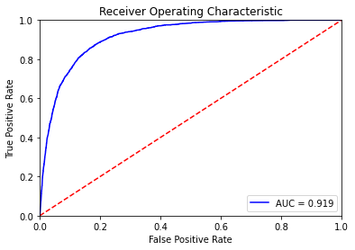

```python
# ROC Eğrisi:
import sklearn.metrics as metrics
# calculate the fpr and tpr for all thresholds of the classification
probs = gbc.predict_proba(x_test)
preds = probs[:,1]
fpr, tpr, threshold = metrics.roc_curve(y_test, preds)
roc_auc = metrics.auc(fpr, tpr)

# method I: plt
plt.title('Receiver Operating Characteristic')
plt.plot(fpr, tpr, 'b', label = 'AUC = %0.3f' % roc_auc)
plt.legend(loc = 'lower right')
plt.plot([0, 1], [0, 1],'r--')
plt.xlim([0, 1])
plt.ylim([0, 1])
plt.ylabel('True Positive Rate')
plt.xlabel('False Positive Rate')
plt.show()
```

## Customer Segmentation

- We are also interested in finding customers who are more likely to buy the investment product. Determine the segment(s) of customers our client should prioritize.
- What makes the customers buy? Tell us which feature we should be focusing more on.

```python
df.head()
```

|  | age | job | marital | education | default | balance | housing | loan | contact | day | month | duration | campaign | y |
| --- | --- | --- | --- | --- | --- | --- | --- | --- | --- | --- | --- | --- | --- | --- |
| 0 | 58 | management | married | tertiary | no | 2143 | yes | no | unknown | 5 | may | 261 | 1 | no |
| 1 | 44 | technician | single | secondary | no | 29 | yes | no | unknown | 5 | may | 151 | 1 | no |
| 2 | 33 | entrepreneur | married | secondary | no | 2 | yes | yes | unknown | 5 | may | 76 | 1 | no |
| 3 | 47 | blue-collar | married | unknown | no | 1506 | yes | no | unknown | 5 | may | 92 | 1 | no |
| 4 | 33 | unknown | single | unknown | no | 1 | no | no | unknown | 5 | may | 198 | 1 | no |

```python
df_date = df.copy()
df_date["year"] = 2019
df_date.head()
```

|  | age | job | marital | education | default | balance | housing | loan | contact | day | month | duration | campaign | y | year |
| --- | --- | --- | --- | --- | --- | --- | --- | --- | --- | --- | --- | --- | --- | --- | --- |
| 0 | 58 | management | married | tertiary | no | 2143 | yes | no | unknown | 5 | may | 261 | 1 | no | 2019 |
| 1 | 44 | technician | single | secondary | no | 29 | yes | no | unknown | 5 | may | 151 | 1 | no | 2019 |
| 2 | 33 | entrepreneur | married | secondary | no | 2 | yes | yes | unknown | 5 | may | 76 | 1 | no | 2019 |
| 3 | 47 | blue-collar | married | unknown | no | 1506 | yes | no | unknown | 5 | may | 92 | 1 | no | 2019 |
| 4 | 33 | unknown | single | unknown | no | 1 | no | no | unknown | 5 | may | 198 | 1 | no | 2019 |

```python
# change months to numeric values
df_date.month = df_date.month.replace("jan","1")
df_date.month = df_date.month.replace("feb","2")
df_date.month = df_date.month.replace("mar","3")
df_date.month = df_date.month.replace("apr","4")
df_date.month = df_date.month.replace("may","5")
df_date.month = df_date.month.replace("jun","6")
df_date.month = df_date.month.replace("jul","7")
df_date.month = df_date.month.replace("aug","8")
df_date.month = df_date.month.replace("oct","10")
df_date.month = df_date.month.replace("nov","11")
df_date.month = df_date.month.replace("dec","12")
```

```python
df_date.head()
```

|  | age | job | marital | education | default | balance | housing | loan | contact | day | month | duration | campaign | y | year |
| --- | --- | --- | --- | --- | --- | --- | --- | --- | --- | --- | --- | --- | --- | --- | --- |
| 0 | 58 | management | married | tertiary | no | 2143 | yes | no | unknown | 5 | 5 | 261 | 1 | no | 2019 |
| 1 | 44 | technician | single | secondary | no | 29 | yes | no | unknown | 5 | 5 | 151 | 1 | no | 2019 |
| 2 | 33 | entrepreneur | married | secondary | no | 2 | yes | yes | unknown | 5 | 5 | 76 | 1 | no | 2019 |
| 3 | 47 | blue-collar | married | unknown | no | 1506 | yes | no | unknown | 5 | 5 | 92 | 1 | no | 2019 |
| 4 | 33 | unknown | single | unknown | no | 1 | no | no | unknown | 5 | 5 | 198 | 1 | no | 2019 |

```python
#create "Date" Feature
df_date["date"] = df_date['year'].map(str) + "/" + df_date['month'].map(str) + "/" + df_date['day'].map(str)
```

```python
df_date.head()
```

|  | age | job | marital | education | default | balance | housing | loan | contact | day | month | duration | campaign | y | year | date |
| --- | --- | --- | --- | --- | --- | --- | --- | --- | --- | --- | --- | --- | --- | --- | --- | --- |
| 0 | 58 | management | married | tertiary | no | 2143 | yes | no | unknown | 5 | 5 | 261 | 1 | no | 2019 | 2019/5/5 |
| 1 | 44 | technician | single | secondary | no | 29 | yes | no | unknown | 5 | 5 | 151 | 1 | no | 2019 | 2019/5/5 |
| 2 | 33 | entrepreneur | married | secondary | no | 2 | yes | yes | unknown | 5 | 5 | 76 | 1 | no | 2019 | 2019/5/5 |
| 3 | 47 | blue-collar | married | unknown | no | 1506 | yes | no | unknown | 5 | 5 | 92 | 1 | no | 2019 | 2019/5/5 |
| 4 | 33 | unknown | single | unknown | no | 1 | no | no | unknown | 5 | 5 | 198 | 1 | no | 2019 | 2019/5/5 |

```python
# Change Format of Date
df_date["date"] = pd.to_datetime(df_date.date,format="%Y-%m-%d")
```

```python
df_date.head()
```

|  | age | job | marital | education | default | balance | housing | loan | contact | day | month | duration | campaign | y | year | date |
| --- | --- | --- | --- | --- | --- | --- | --- | --- | --- | --- | --- | --- | --- | --- | --- | --- |
| 0 | 58 | management | married | tertiary | no | 2143 | yes | no | unknown | 5 | 5 | 261 | 1 | no | 2019 | 2019-05-05 |
| 1 | 44 | technician | single | secondary | no | 29 | yes | no | unknown | 5 | 5 | 151 | 1 | no | 2019 | 2019-05-05 |
| 2 | 33 | entrepreneur | married | secondary | no | 2 | yes | yes | unknown | 5 | 5 | 76 | 1 | no | 2019 | 2019-05-05 |
| 3 | 47 | blue-collar | married | unknown | no | 1506 | yes | no | unknown | 5 | 5 | 92 | 1 | no | 2019 | 2019-05-05 |
| 4 | 33 | unknown | single | unknown | no | 1 | no | no | unknown | 5 | 5 | 198 | 1 | no | 2019 | 2019-05-05 |

## Find Recency, Monetary and Frequency

- Recency — How many days ago was their last purchase?
- Frequency — How many times has the customer purchased from our store?
- Monetary Value — How much do they spend?

```python
from datetime import date
import datetime as dt
today = dt.datetime(2020,8,25)
print(today)
```

```
2020-08-25 00:00:00
```

```python
# Recency and Monetary
data_x = df_date.groupby(df.index).agg({'date': lambda x: (today - x.max()).days})
data_x.head()
```

|  | date |
| --- | --- |
| 0 | 478 |
| 1 | 478 |
| 2 | 478 |
| 3 | 478 |
| 4 | 478 |

```python
data_x["campaign"] = df_date.campaign
data_x["duration"] = df_date.duration
data_x.head()
```

[output not shown]

```python
# Change Column Name
data_x.rename(columns= {'date': 'Recency',
                        'campaign': 'Frequency',
                        'duration': 'Monetary'}, inplace= True)
data_x.head()
```

|  | Recency | Frequency | Monetary |
| --- | --- | --- | --- |
| 0 | 478 | 1 | 261 |
| 1 | 478 | 1 | 151 |
| 2 | 478 | 1 | 76 |
| 3 | 478 | 1 | 92 |
| 4 | 478 | 1 | 198 |

## RFM Segmentation

- Customers with the lowest recency, highest frequency and monetary amounts considered as top customers.

```python
rfm_table = data_x.copy()
```

```python
#Frequency bulma
def FScore(x,p,d):
    if x <= d[p][0.20]:
        return 0
    elif x <= d[p][0.40]:
        return 1
    elif x <= d[p][0.60]:
        return 2
    elif x <= d[p][0.80]:
        return 3
    else:
        return 4

quantiles = rfm_table.quantile(q=[0.20,0.40,0.60,0.80])
quantiles = quantiles.to_dict()
rfm_table['Freq_Tile'] = rfm_table['Frequency'].apply(FScore, args=('Frequency',quantiles,))

#Recency
rfm_table = rfm_table.sort_values('Recency',ascending=True)
rfm_table['Rec_Tile'] = pd.qcut(rfm_table['Recency'],5,labels=False)

#Monetary
rfm_table['Mone_Tile'] = pd.qcut(rfm_table['Monetary'],5,labels=False)

# instead of zero, plus 1
rfm_table['Rec_Tile'] = rfm_table['Rec_Tile'] + 1
rfm_table['Freq_Tile'] = rfm_table['Freq_Tile'] + 1
rfm_table['Mone_Tile'] = rfm_table['Mone_Tile'] + 1

# Add to dataframe
rfm_table['RFM Score'] = rfm_table['Rec_Tile'].map(str) + rfm_table['Freq_Tile'].map(str) + rfm_table['Mone_Tile'].map(str)
rfm_table.head()
```

|  | Recency | Frequency | Monetary | Freq_Tile | Rec_Tile | Mone_Tile | RFM Score |
| --- | --- | --- | --- | --- | --- | --- | --- |
| 27728 | 242 | 1 | 333 | 1 | 1 | 4 | 114 |
| 27727 | 247 | 1 | 119 | 1 | 1 | 2 | 112 |
| 27726 | 256 | 1 | 232 | 1 | 1 | 4 | 114 |
| 27725 | 257 | 1 | 136 | 1 | 1 | 2 | 112 |
| 27723 | 258 | 1 | 234 | 1 | 1 | 4 | 114 |

```python
rfm_table[rfm_table['RFM Score'] == '555'].sort_values('Monetary', ascending=False).head()
```

|  | Recency | Frequency | Monetary | Freq_Tile | Rec_Tile | Mone_Tile | RFM Score |
| --- | --- | --- | --- | --- | --- | --- | --- |
| 31325 | 532 | 5 | 2330 | 5 | 5 | 5 | 555 |
| 33629 | 493 | 5 | 1333 | 5 | 5 | 5 | 555 |
| 34352 | 479 | 5 | 1063 | 5 | 5 | 5 | 555 |
| 30524 | 567 | 6 | 985 | 5 | 5 | 5 | 555 |
| 29376 | 570 | 5 | 981 | 5 | 5 | 5 | 555 |

## Summing the RFM Score

- One of the most straightforward methods is to sum our scores to a single number and define RFM levels for each score range.

```python
# Calculate RFM_Score
rfm_table['RFM_Sum'] = rfm_table[['Freq_Tile','Rec_Tile','Mone_Tile']].sum(axis=1)
rfm_table.head()
```

|  | Recency | Frequency | Monetary | Freq_Tile | Rec_Tile | Mone_Tile | RFM Score | RFM_Sum |
| --- | --- | --- | --- | --- | --- | --- | --- | --- |
| 27728 | 242 | 1 | 333 | 1 | 1 | 4 | 114 | 6 |
| 27727 | 247 | 1 | 119 | 1 | 1 | 2 | 112 | 4 |
| 27726 | 256 | 1 | 232 | 1 | 1 | 4 | 114 | 6 |
| 27725 | 257 | 1 | 136 | 1 | 1 | 2 | 112 | 4 |
| 27723 | 258 | 1 | 234 | 1 | 1 | 4 | 114 | 6 |

## Making Segmentation For Customers Depends On RFM Sum Score

- We can get creative and hypothesize about what each score range entails, but for this exercise I will take inspiration from some common segment names.

```python
# Define rfm_level function
def rfm_level(df):
    if df['RFM_Sum'] >= 9:
        return 'Can\'t Loose Them'
    elif ((df['RFM_Sum'] >= 8) and (df['RFM_Sum'] < 9)):
        return 'Champions'
    elif ((df['RFM_Sum'] >= 7) and (df['RFM_Sum'] < 8)):
        return 'Loyal'
    elif ((df['RFM_Sum'] >= 6) and (df['RFM_Sum'] < 7)):
        return 'Potential'
    elif ((df['RFM_Sum'] >= 5) and (df['RFM_Sum'] < 6)):
        return 'Promising'
    elif ((df['RFM_Sum'] >= 4) and (df['RFM_Sum'] < 5)):
        return 'Needs Attention'
    else:
        return 'Require Activation'
# Create a new variable RFM_Level
rfm_table['RFM_Level'] = rfm_table.apply(rfm_level, axis=1)
# Print the header with top 5 rows to the console
rfm_table.head()
```

|  | Recency | Frequency | Monetary | Freq_Tile | Rec_Tile | Mone_Tile | RFM Score | RFM_Sum | RFM_Level |
| --- | --- | --- | --- | --- | --- | --- | --- | --- | --- |
| 27728 | 242 | 1 | 333 | 1 | 1 | 4 | 114 | 6 | Potential |
| 27727 | 247 | 1 | 119 | 1 | 1 | 2 | 112 | 4 | Needs Attention |
| 27726 | 256 | 1 | 232 | 1 | 1 | 4 | 114 | 6 | Potential |
| 27725 | 257 | 1 | 136 | 1 | 1 | 2 | 112 | 4 | Needs Attention |
| 27723 | 258 | 1 | 234 | 1 | 1 | 4 | 114 | 6 | Potential |

```python
rfm_table[rfm_table['RFM Score'] == '555'].sort_values('Monetary', ascending=False).head()
```

|  | Recency | Frequency | Monetary | Freq_Tile | Rec_Tile | Mone_Tile | RFM Score | RFM_Sum | RFM_Level |
| --- | --- | --- | --- | --- | --- | --- | --- | --- | --- |
| 31325 | 532 | 5 | 2330 | 5 | 5 | 5 | 555 | 15 | Can't Loose Them |
| 33629 | 493 | 5 | 1333 | 5 | 5 | 5 | 555 | 15 | Can't Loose Them |
| 34352 | 479 | 5 | 1063 | 5 | 5 | 5 | 555 | 15 | Can't Loose Them |
| 30524 | 567 | 6 | 985 | 5 | 5 | 5 | 555 | 15 | Can't Loose Them |
| 29376 | 570 | 5 | 981 | 5 | 5 | 5 | 555 | 15 | Can't Loose Them |

```python
rfm_table["RFM_Level"].value_counts()
```

```
Can't Loose Them      19541
Champions              6572
Loyal                  5840
Potential              3721
Promising              2475
Needs Attention        1273
Require Activation      499
Name: RFM_Level, dtype: int64
```

```python
# Calculate average values for each RFM_Level, and return a size of each segment
rfm_level_agg = rfm_table.groupby('RFM_Level').agg({
    'Recency': 'mean',
    'Frequency': 'mean',
    'Monetary': ['mean', 'count']}).round(1)
# Print the aggregated dataset
print(rfm_level_agg)
```

```
                   Recency Frequency Monetary
                      mean      mean     mean  count
RFM_Level
Can't Loose Them     466.1       3.5    351.9  19541
Champions            435.8       3.1    216.4   6572
Loyal                414.3       2.6    172.1   5840
Needs Attention      339.2       1.4     80.1   1273
Potential            398.0       1.6    130.1   3721
Promising            379.8       1.4    102.6   2475
Require Activation   287.3       1.0     58.1    499
```